# Zadanie domowe - EDA Danych dotyczących Irysów

- Twoim zadaniem jest wykonanie analizy danych zawartych w załączonym pliku CSV (`25__iris.csv`).
- Plik znajduje się pod video. Pamiętaj, żeby wrzucić plik do tego samego folderu, w którym znajduje się ten notebook.
- Wykorzystaj nowo nabytą wiedzę z biblioteki `Pandas`
- Jeżeli jest taka konieczność posiłkuj się [code explainerem](https://codeexplainer.imprv.ai/) lub / i [data chatterem](https://datachatter.imprv.ai/) (który również te dane ma dostępne).
- Prześlij na discordzie notebook z rozwiązaniem (`#modul-4-zad1`)
- Pamiętaj:
1. Nie spiesz się
2. Potraktuj zadanie domowe jak prawdziwy projekt
3. Dodawaj opisy, obserwacje, wnioski
4. Dodaj wizualizacje
5. Dodaj konkluzję i wnioski końcowe

Powodzenia!!! I mega zabawy!

## O Danych

Zbiór danych zawiera informacje o trzech gatunkach irysów: Iris setosa, Iris versicolor, i Iris virginica.

Dane obejmują pomiary czterech cech: długość i szerokość działki kielicha oraz długość i szerokość płatka.

Każdy wiersz w zbiorze danych reprezentuje pojedynczy kwiat, a wartości pomiarów są podane w centymetrach.

Zbiór składa się z 150 próbek, po 50 dla każdego gatunku, i jest szeroko stosowany jako podstawowy zbiór danych do testowania algorytmów klasyfikacji oraz w nauce o danych i uczeniu maszynowym.

Kolumny:

- **długość kielicha (sepal length)** - Długość kielicha w cm
- **szerokość kielicha (sepal width)** - Szerokość kielicha w cm
- **długość płatka (petal length)** - Długość płatka w cm
- **szerokość płatka (petal width)** - Szerokość płatka w cm
- **klasa (class)** - Klasa irysa (setosa, versicolor, virginica)

```python
import pandas as pd
```

```python
df = pd.read_csv('25__iris.csv', sep=",")
df
```

|  | długość kielicha (sepal length) | szerokość kielicha (sepal width) | długość płatka (petal length) | szerokość płatka (petal width) | klasa (class) |
| --- | --- | --- | --- | --- | --- |
| 0 | 5.1 | 3.5 | 1.4 | 0.2 | Iris-setosa |
| 1 | 4.9 | 3.0 | 1.4 | 0.2 | Iris-setosa |
| 2 | 4.7 | 3.2 | 1.3 | 0.2 | Iris-setosa |
| 3 | 4.6 | 3.1 | 1.5 | 0.2 | Iris-setosa |
| 4 | 5.0 | 3.6 | 1.4 | 0.2 | Iris-setosa |
| ... | ... | ... | ... | ... | ... |
| 145 | 6.7 | 3.0 | 5.2 | 2.3 | Iris-virginica |
| 146 | 6.3 | 2.5 | 5.0 | 1.9 | Iris-virginica |
| 147 | 6.5 | 3.0 | 5.2 | 2.0 | Iris-virginica |
| 148 | 6.2 | 3.4 | 5.4 | 2.3 | Iris-virginica |
| 149 | 5.9 | 3.0 | 5.1 | 1.8 | Iris-virginica |

150 rows × 5 columns

# **AMELIA's Garden**

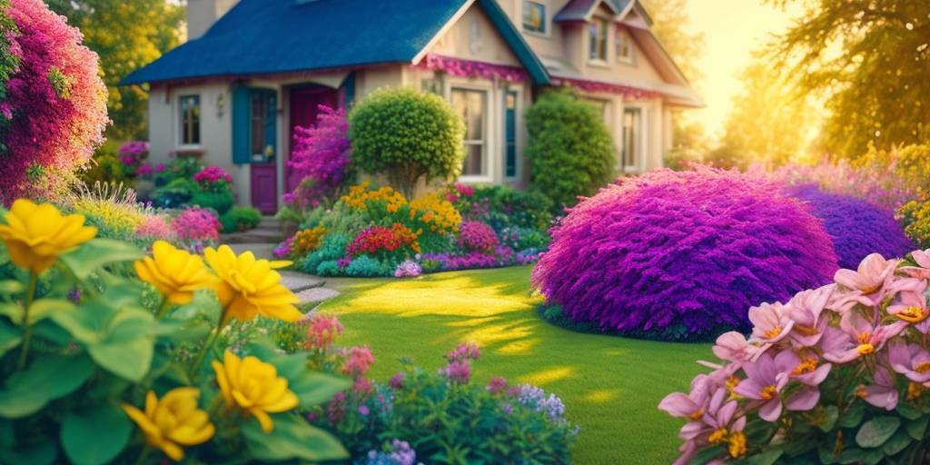

# **Ekploratacyjna analiza zbioru danych** zawierających informacje o trzech gatunkach irysów: *Iris setosa, Iris versicolor, Iris virginica.*

## SPIS TREŚCI

### 1. Wstęp

### 2. Ogólny przegląd danych

### 3. Analiza brakujących wartości

### 4. Analiza pojedynczych zmiennych

### 5. Transformacja danych

### 6. Analiza relacji między zmiennymi¶

### 7. Analiza wartości odstających

### 8. Podsumowanie

## **1. Wstęp**

### Sześcioletnia AMELKA marzy o cudownym ogrodzie takim jak z bajek.

### Pewnego dnia, kiedy wybierała ze swoim ojcem rośliny ozdobne do ogrodu zobaczyła pewien gatunek kwiatów, który przykuł jej uwagę. Były to IRYSY. Szybko poprosiła swojego tatę aby zasadził w ich ogrodzie te piękne kwiaty. Jednak w sklepie ogrodniczym były 3 gatunki irysów.

### Oboje postanowili aby przed zakupem dokładnie zastanowić się, który rodzaj wybrać. Mała AMELKA chcąc mądrze dokonać wyboru, poprosiła swojego tatę aby ten opowiedział jej czym różnią się poszczególne gatunki irysów.

### TATA nie chcąc zawieść swojej córki natychmiast przystapił do analizy, która powinna przyniesć zakładany efekt. I w tym celu postanowił wykorzystać Sztuczną Inteligencję. Wgrał niezbędne dane i zaczął analizę EDA.

## **2. Ogólny przegląd danych**

```python
# Tata najpierw zaczął od przeglądu 10 losowych wierszy.
df.sample(10)
```

|  | długość kielicha (sepal length) | szerokość kielicha (sepal width) | długość płatka (petal length) | szerokość płatka (petal width) | klasa (class) |
| --- | --- | --- | --- | --- | --- |
| 69 | 5.6 | 2.5 | 3.9 | 1.1 | Iris-versicolor |
| 140 | 6.7 | 3.1 | 5.6 | 2.4 | Iris-virginica |
| 145 | 6.7 | 3.0 | 5.2 | 2.3 | Iris-virginica |
| 68 | 6.2 | 2.2 | 4.5 | 1.5 | Iris-versicolor |
| 65 | 6.7 | 3.1 | 4.4 | 1.4 | Iris-versicolor |
| 128 | 6.4 | 2.8 | 5.6 | 2.1 | Iris-virginica |
| 57 | 4.9 | 2.4 | 3.3 | 1.0 | Iris-versicolor |
| 45 | 4.8 | 3.0 | 1.4 | 0.3 | Iris-setosa |
| 6 | 4.6 | 3.4 | 1.4 | 0.3 | Iris-setosa |
| 96 | 5.7 | 2.9 | 4.2 | 1.3 | Iris-versicolor |

```python
# Potem wyświetlił informacje o zbiorze danych zawierających informacje o trzech gatunkach irysów.
df.info()
```

```
<class 'pandas.core.frame.DataFrame'>
RangeIndex: 150 entries, 0 to 149
Data columns (total 5 columns):
 #   Column                            Non-Null Count  Dtype
---  ------                            --------------  -----
 0   długość kielicha (sepal length)   150 non-null    float64
 1   szerokość kielicha (sepal width)  150 non-null    float64
 2   długość płatka (petal length)     150 non-null    float64
 3   szerokość płatka (petal width)    150 non-null    float64
 4   klasa (class)                     150 non-null    object
dtypes: float64(4), object(1)
memory usage: 6.0+ KB
```

```python
# Wyfiltrował ze zbioru danych podstawowe informacje statystyczne.
df.describe().round(2).T
```

|  | count | mean | std | min | 25% | 50% | 75% | max |
| --- | --- | --- | --- | --- | --- | --- | --- | --- |
| długość kielicha (sepal length) | 150.0 | 5.84 | 0.83 | 4.3 | 5.1 | 5.80 | 6.4 | 7.9 |
| szerokość kielicha (sepal width) | 150.0 | 3.05 | 0.43 | 2.0 | 2.8 | 3.00 | 3.3 | 4.4 |
| długość płatka (petal length) | 150.0 | 3.76 | 1.76 | 1.0 | 1.6 | 4.35 | 5.1 | 6.9 |
| szerokość płatka (petal width) | 150.0 | 1.20 | 0.76 | 0.1 | 0.3 | 1.30 | 1.8 | 2.5 |

## **3. Analiza brakujących wartości**

```python
# Sprawdził czy nie brakuje żadnych danch.
df.isnull().sum()
# okazało się, że NIE. Wobec tego mógł przystąpić do kolejnego etapu.
```

```
długość kielicha (sepal length)     0
szerokość kielicha (sepal width)    0
długość płatka (petal length)       0
szerokość płatka (petal width)      0
klasa (class)                       0
dtype: int64
```

## **4. Analiza pojedynczych zmiennych**

```python
# Tata potrzebuje teraz podstawowe informacje statystyczne dla każdego z gatunków irysów.
stat_gatunek = df.groupby('klasa (class)', as_index=False).agg(['mean', 'std', 'min', 'max']).round(2)
stat_gatunek
# Po wygenerowaniu statystyk zaobserwował już pewne różnice.
```

|  | klasa (class) | długość kielicha (sepal length) mean | długość kielicha (sepal length) std | długość kielicha (sepal length) min | długość kielicha (sepal length) max | szerokość kielicha (sepal width) mean | szerokość kielicha (sepal width) std | szerokość kielicha (sepal width) min | szerokość kielicha (sepal width) max | długość płatka (petal length) mean | długość płatka (petal length) std | długość płatka (petal length) min | długość płatka (petal length) max | szerokość płatka (petal width) mean | szerokość płatka (petal width) std | szerokość płatka (petal width) min | szerokość płatka (petal width) max |
| --- | --- | --- | --- | --- | --- | --- | --- | --- | --- | --- | --- | --- | --- | --- | --- | --- | --- |
| 0 | Iris-setosa | 5.01 | 0.35 | 4.3 | 5.8 | 3.42 | 0.38 | 2.3 | 4.4 | 1.46 | 0.17 | 1.0 | 1.9 | 0.24 | 0.11 | 0.1 | 0.6 |
| 1 | Iris-versicolor | 5.94 | 0.52 | 4.9 | 7.0 | 2.77 | 0.31 | 2.0 | 3.4 | 4.26 | 0.47 | 3.0 | 5.1 | 1.33 | 0.20 | 1.0 | 1.8 |
| 2 | Iris-virginica | 6.59 | 0.64 | 4.9 | 7.9 | 2.97 | 0.32 | 2.2 | 3.8 | 5.55 | 0.55 | 4.5 | 6.9 | 2.03 | 0.27 | 1.4 | 2.5 |

```
array([[<Axes: title={'center': 'długość kielicha (sepal length)'}>,
        <Axes: title={'center': 'szerokość kielicha (sepal width)'}>],
       [<Axes: title={'center': 'długość płatka (petal length)'}>,
        <Axes: title={'center': 'szerokość płatka (petal width)'}>]],
      dtype=object)
```

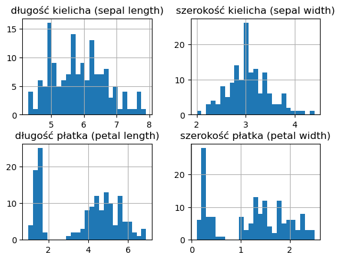

```python
# Spróbował wykonać histogram, który jest podstawowym narzędziem do analizy eksploracyjnej danych, pomagającym lepiej zrozumieć strukturę i cechy zestawu danych.
df.hist(bins=25)
# Po wygenerowaniu histogramu mógł teraz zwizualizować i porównać rozkład danych.
```

```python
# Analizując uzyskane powyżej informacje wybrał do swojej analizy "średnią arytmetyczną" spośród uzyskanych statystyk.
mean_stat_gatunek = df.groupby('klasa (class)',as_index=False).mean().round(2)
mean_stat_gatunek
```

|  | klasa (class) | długość kielicha (sepal length) | szerokość kielicha (sepal width) | długość płatka (petal length) | szerokość płatka (petal width) |
| --- | --- | --- | --- | --- | --- |
| 0 | Iris-setosa | 5.01 | 3.42 | 1.46 | 0.24 |
| 1 | Iris-versicolor | 5.94 | 2.77 | 4.26 | 1.33 |
| 2 | Iris-virginica | 6.59 | 2.97 | 5.55 | 2.03 |

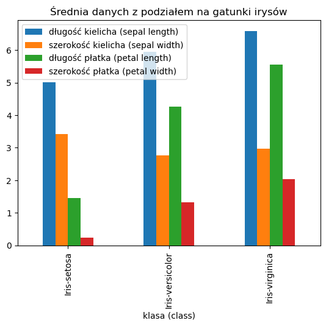

```python
# Aby móc lepiej zobrazować uzyskane dane, postanowił zwizualizować je w postaci wykresu.
mean_stat_gatunek.plot(kind='bar', x='klasa (class)', title="Średnia danych z podziałem na gatunki irysów")
# Dzięki temu wykresowi teraz lepiej może zauważyć różnice poszczególnych gatunków irysów.
```

## Po przeprowadzeniu 4 etapów swojej analizy TATA już wiedział na co zwrócić uwagę aby móc rozróżnić analizowane gatunki irysów.

## Swoje obserwacje i wnioski potwierdzi w kolejnych etapach EDA.

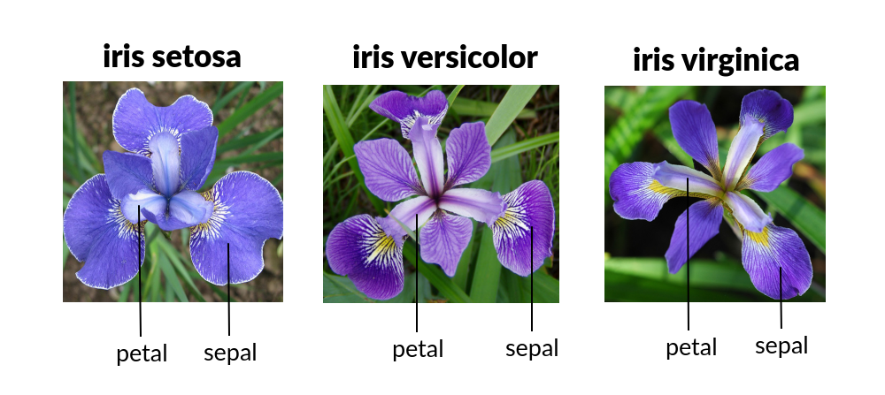

## **5. Transformacja danych**

## TATA stwierdził, że skoro zbiór dancych nie zawiera braków i jakość zawartych w nim danych jest dobra, pominie ten etap analizy i przejdzie do następnego.

## **6. Analiza relacji między zmiennymi**

## TATA aby móc lepiej przyjrzeć się różnicom i relacjom między wartościami zmiennych postanowił zwizualizować na wykresach

```python
# W związku z tym postanowił przypisać odpowiednim gatunkom irysów - kolory, które pomogą odzwierciedlać uzyskane wyniki relacji na wykresach.

df = df.rename(columns={"klasa (class)": "gatunek"})

# I tak:
## gatunkowi 'Iris-setosa' przypisano kolor nr 10 (odcień niebieskiego),
## gatunkowi 'Iris-versicolor' przypisano kolor nr 20 (odcień zielonego),
## gatunkowi 'Iris-virginica' przypisano kolor nr 30 (odcień czerwonego),

def color_column(gatunek) :
    if gatunek == 'Iris-setosa':
        return 10
    elif gatunek == 'Iris-versicolor':
        return 20
    elif gatunek == 'Iris-virginica':
        return 30

df["color_column"] = df["gatunek"].apply(color_column)
df
```

|  | długość kielicha (sepal length) | szerokość kielicha (sepal width) | długość płatka (petal length) | szerokość płatka (petal width) | gatunek | color_column |
| --- | --- | --- | --- | --- | --- | --- |
| 0 | 5.1 | 3.5 | 1.4 | 0.2 | Iris-setosa | 10 |
| 1 | 4.9 | 3.0 | 1.4 | 0.2 | Iris-setosa | 10 |
| 2 | 4.7 | 3.2 | 1.3 | 0.2 | Iris-setosa | 10 |
| 3 | 4.6 | 3.1 | 1.5 | 0.2 | Iris-setosa | 10 |
| 4 | 5.0 | 3.6 | 1.4 | 0.2 | Iris-setosa | 10 |
| ... | ... | ... | ... | ... | ... | ... |
| 145 | 6.7 | 3.0 | 5.2 | 2.3 | Iris-virginica | 30 |
| 146 | 6.3 | 2.5 | 5.0 | 1.9 | Iris-virginica | 30 |
| 147 | 6.5 | 3.0 | 5.2 | 2.0 | Iris-virginica | 30 |
| 148 | 6.2 | 3.4 | 5.4 | 2.3 | Iris-virginica | 30 |
| 149 | 5.9 | 3.0 | 5.1 | 1.8 | Iris-virginica | 30 |

150 rows × 6 columns

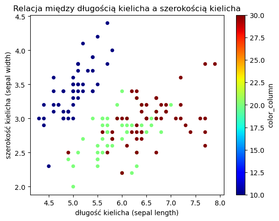

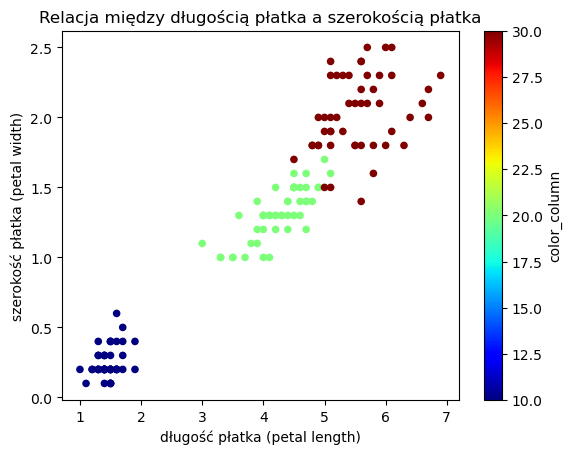

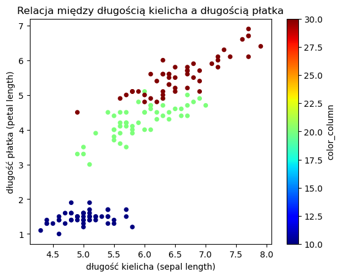

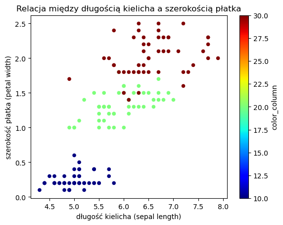

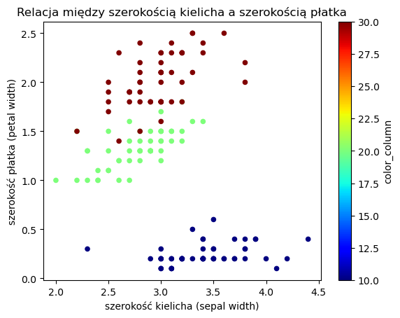

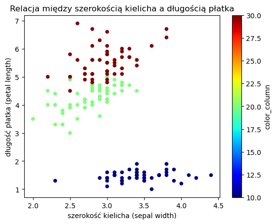

```python
# Obserwując tabelę ze zbiorem danych TATA postanowił wygenerować wykresy z następujacymi relacjami:
df.plot(kind='scatter', x='długość kielicha (sepal length)', y='szerokość kielicha (sepal width)', title="Relacja między długością kielicha a szerokością kielicha", c='color_column', colormap='jet')
df.plot(kind='scatter', x='długość płatka (petal length)', y='szerokość płatka (petal width)', title="Relacja między długością płatka a szerokością płatka", c='color_column', colormap='jet')
df.plot(kind='scatter', x='długość kielicha (sepal length)', y='długość płatka (petal length)', title="Relacja między długością kielicha a długością płatka", c='color_column', colormap='jet')
df.plot(kind='scatter', x='długość kielicha (sepal length)', y='szerokość płatka (petal width)', title="Relacja między długością kielicha a szerokością płatka", c='color_column', colormap='jet')
df.plot(kind='scatter', x='szerokość kielicha (sepal width)', y='szerokość płatka (petal width)', title="Relacja między szerokością kielicha a szerokością płatka", c='color_column', colormap='jet')
df.plot(kind='scatter', x='szerokość kielicha (sepal width)', y='długość płatka (petal length)', title="Relacja między szerokością kielicha a długością płatka", c='color_column', colormap='jet')
```

### Po wygenerowaniu wykresów z relacjami i zależnościami pomiędzy wartościami zmiennych TATA od razu zuważył, że wartości pomiarów jednego gatunku irysów różnią się znacząco od pozostałych dwóch.

### Róźnice w relacji "między długością płatka a jego szerokością" najbardziej pokazują jak poszczególne gatunki różnią sie od siebie i na co zwrócić uwagę przy ich wyborze. Co potwierdziła wizualizacja korelacji między zmiennymi.

```python
# Tata dla pewności wykonał macież korelacyjną
df[["długość kielicha (sepal length)","szerokość kielicha (sepal width)", "długość płatka (petal length)", "szerokość płatka (petal width)"]].corr()
```

|  | długość kielicha (sepal length) | szerokość kielicha (sepal width) | długość płatka (petal length) | szerokość płatka (petal width) |
| --- | --- | --- | --- | --- |
| długość kielicha (sepal length) | 1.000000 | -0.109369 | 0.871754 | 0.817954 |
| szerokość kielicha (sepal width) | -0.109369 | 1.000000 | -0.420516 | -0.356544 |
| długość płatka (petal length) | 0.871754 | -0.420516 | 1.000000 | 0.962757 |
| szerokość płatka (petal width) | 0.817954 | -0.356544 | 0.962757 | 1.000000 |

### Niemniej jednak analizę trzeba doprowadzić do końca i podsumować całość analizy i wobec tego TATA przystapił do osatniego etapu EDA przed Podsumowaniem.

## **7. Analiza wartości odstających**

```
długość kielicha (sepal length)        Axes(0.125,0.11;0.168478x0.77)
długość płatka (petal length)       Axes(0.327174,0.11;0.168478x0.77)
szerokość kielicha (sepal width)    Axes(0.529348,0.11;0.168478x0.77)
szerokość płatka (petal width)      Axes(0.731522,0.11;0.168478x0.77)
dtype: object
```

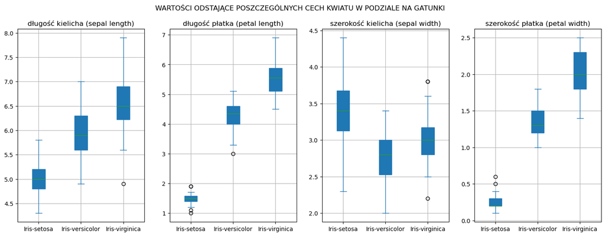

```python
# TATA przystąpił do generowania wykresów pudełkowych aby zobaczyć jak rozkładają się wartości odstające dla poszczególnych zmiennych.
df.plot(kind='box', by="gatunek", column=["długość kielicha (sepal length)", "szerokość kielicha (sepal width)", "długość płatka (petal length)", "szerokość płatka (petal width)"], title="WARTOŚCI ODSTAJĄCE POSZCZEGÓLNYCH CECH KWIATU W PODZIALE NA GATUNKI", fontsize= 10, figsize=(18, 6), layout=(1, 4), grid=True, patch_artist=True)
```

### Wartości odstające, które są wyświetlane jako pojedyncze punkty poza „wąsami” wykresu identyfikują możliwość występowania błędów lub nietypowych obserwacji w danych. W tym przypadku TATA zauważył i wywnioskował, że wartości odstające nie stanowią problemu w analizie danych i zignorował je. Wyszedł z założenia, że mogą być wynikiem nietypowych obserwacji i pewnych wyjątków podczas pomiarów roślin.

## **8. PODSUMOWANIE**

### Ponieważ celem jak to TATA nazwał "AMELKowej analizy EDA" powinno być rozróżnienie i wybór najpiekniejszego irysa z gatunków *Iris setosa, Iris versicolor, Iris virginica*, stwierdził, że najlepiej będzie wytłumaczyć córeczce aby przy wyborze zwracać uwagę na wielkość płatka.

### Zmotywowany TATA w sposób przytępny dla swojej ukochanej sześciolatki wyjaśnił jej wszystkie swoje spostrzeżenia, które wygenerowała analiza EDA.

### AMELKA, która z wielkim zaciekawieniem wysłuchała interpretacji swojego TATY na temat irysów i stwierdziła w sposób zwykle przyjęty dla dzieci (czyli bez zbędnych komentarzy), że skoro nie tak łatwo odróżnić "te irysy" - ***to kupmy i zasadźmy wszystkie jakie są, przecież i tak sa piękne***

## Zdezorientowny TATA ucieszył się bardzo i wytłumaczył sobie, że najlepszą interpretacją każdej analizy jest rzeczywiście ta najprostsza a przy jej tworzeniu ograniczyć nas może tylko wyobraźnia ***albo brak danych***.

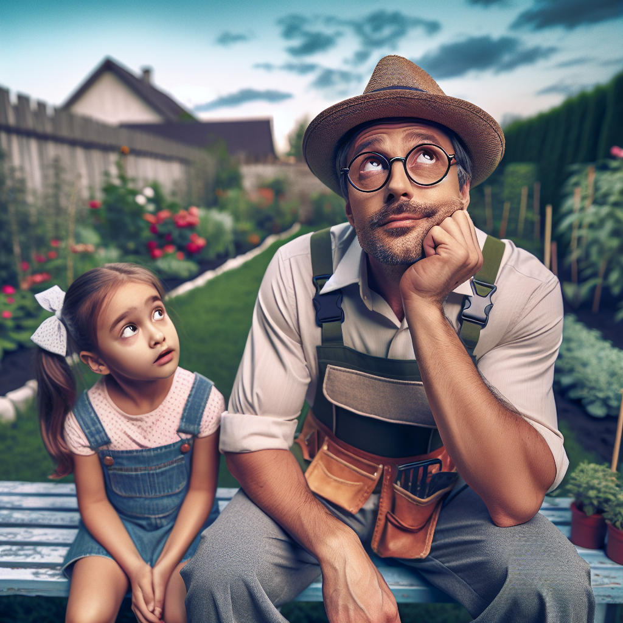